# 6.041x - Unit 1: Probability Models and Axioms

## Core Concepts:

- **Sample space $\mathbf{\Omega}$** contains list (set) of all possible outcomes
  - Mutually exhaustive
  - Collectively exhaustive
  - At the right granularity
- **Event:** a subset of the sample space
- **Fundamental Axioms:**
  1. Nonnegativity: $P(A) >= 0$
  2. Normalization: $P(\Omega) = 1$
  3. Finite (Countable) Additivity: If $A \cap B = \emptyset$, then $P(A \cup B) = P(A) + P(B)$
     - Generally: $A \cap B \neq \emptyset$, then $P(A \cup B) = P(A) + P(B) - P(A \cap B)$
     - **NOTE:** additivity only holds for countable (i.e. sequencable) sequences of events (works for area, but not unit square, real line, etc.)
- **Consequences:**
  - $P(A) <= 1$
  - $P(\emptyset) = 0$
  - $P(A) + P(A^c) = 1$
  - $P(\{s_1,s_2,...,s_k\}) = P(s_1) + P(s_2) + ... + P(s_k)$
  - If $A \subset B$, then $P(A) <= P(B)$
  - $P(A \cup B \cup C) = P(A) + P(A^c \cap B) + P(A^c \cap B^c \cap C)$
- **Discrete Uniform Law:** if $\Omega$ consists of n equally likely elements, and event A consists of k elements. then: $\mathbf{P(A) = k * \frac{1}{n}}$
- For a continuous sample space, **Probability = Area** (Uniform Probability Law)
- **Probability calculations:**
  1. Specify sample space
  2. Specify probability law
  3. Identify event of interest
  4. Calculate outcome
- Probability can be interpreted as:
  - Frequencies
  - Descriptions of beliefs
  - Betting preferences

## Mathematical Background:

### Sets:

- A collection of distinct elements
  - e.g. {a, b, c, d} (finite set); Real numbers (infinite set)
- $x \in S$ --> x is an element of S (and v.v., $x \notin S$)
- Specifying a set: {$x \in S: \cos{x} > \frac12$}
- Universal set: $\Omega$
- Complement of $S$: $S^c$
  - $x \in S^c$ if $x \in \Omega$ AND $x \notin S$
  - $(S^c)^c = S$
- Empty set: $\Omega^c = \emptyset$
- Subsets: S is a subset of T if $S \subset T$ (if $x \in S$, then $x \in T$)
  - S can be smaller or equal to T
- Unions: $x \in S \cup T$ implies $x \in S$ or $x \in T$
- Intersections: $x \in S \cap T$ implies $x \in S$ and $x \in T$
- Infinite collection of sets: $S_n,\ n = 1,2,3...$
  - $x \in \bigcup\limits_{n} S_n$ if $x \in S_n$ for some n
  - $x \in \bigcap\limits_{n} S_n$ if $x \in S_n$ for all n
- Distributive set properties:
  - $S \cap (T \cup U) = (S \cap T) \cup (S \cap U)$
  - $S \cup (T \cap U) = (S \cup T) \cap (S \cup U)$

### De Morgan's Laws:

- Allow transfer between unions and intersections:
1. $(S \cap T)^c = S^c \cup T^c$
   - Or formally, $(\bigcap\limits_{n}S_n)^c = \bigcup\limits_{n}S_n^c$
1. $(S \cup T)^c = S^c \cap T^c$
   - Or formally, $(\bigcup\limits_{n}S_n)^c = \bigcap\limits_{n}S_n^c$

### Sequences and their Limits:

- Any kind of set possible, e.g. $S = \mathbb{R}$ (all real numbers), $S = \mathbb{R^n}$
- Sequence: a function that associates an element of a set S for any natural number i
  - Evaluate $f(i)$, get $a_i$ (i'th entry in sequence)
- Example sequences: $a_1, a_2, a_3,...$, or $a_i = \{a_i\}$ where $i \in \mathbb{N} = \{1, 2, 3,...\}$ and $a_i \in S$
- Typically care if sequence converges to certain number a: $\lim\limits_{i \to \infty}a_i = a$

### When Does a Sequence Converge?

- If $a_i < a_{i+1}$, then either sequence converges to $\infty$ or some real number a
- If $|a_i - a| <= b_i$ for all i and $b_i \to 0$, then $a_i \to a$
  - "Sandwich argument"

### Infinite Series:

- Defined as $\sum\limits_{i=1}^{\infty}a_i = \lim\limits_{n \to \infty} \sum\limits_{i=1}^{n}a_i$ --provided the limit exists
  - If $a_i > 0$ for all $a_i$ --> limit exists
  - If $a_i$ terms not all same sign:
    - Limit does not exist
    - Limit may exist but depend on order of summation
  - Limit exists and independant of order of summation if $\sum\limits_{i=1}^{\infty}|a_i| < \infty$

### Geometric Series:

- $S = \sum\limits_{i=0}^{\infty}\alpha^i = 1 + \alpha + \alpha^2 + ... = \frac{1}{1-\alpha}$ if $|\alpha| < 1$
  - Proof: $S = 1 + \sum\limits_{i=1}^{\infty}\alpha^i = 1 + \alpha \sum\limits_{i=0}^{\infty}\alpha^i = 1 + \alpha S \to S (1 - \alpha) = 1 \to S = \frac{1}{1 - \alpha}$ (assuming S < $\infty$)

### Order of Summation in a Series:

- If $\sum|a_{ij}| < \infty$, then order doesn't matter: $\sum\limits_{i=1}^{\infty}\sum\limits_{j=1}^{\infty}a_{ij} = \sum\limits_{j=1}^{\infty}\sum\limits_{i=1}^{\infty}a_{ij}$
  - Otherwise, somehow it does?!

### Countable and Uncountable Sets:

- Countable sets: each element of set can be matched 1:1 with positive integers
  - $\{a_1, a_2, a_3,...\} = \Omega$
  - Examples of countable sets:
    - Positive integers
    - All integers: 0, 1, -1, 2, -2,...
    - Pairs of positive integers
    - Rational numbers $q$, with $0 < q < 1$
- Uncountable sets: continuous things
  - Examples of uncountable sets:
    - The interval [0,1]
    - The reals, a plane, etc.
- Why the reals are uncountable --> Cantor's diagonalization argument

## Lecture 1 Exercises:

**#1 Are these legitimate sample spaces?**

A. $\Omega$ = {Heads and rain, Heads and no rain, Tails}

- Mutually exclusive + collectively exhaustive, so yes

B. $\Omega$ = {Heads and rain, Tails and no rain, Tails}

- Not mutually exclusive --> No

**#2 Let A and B be events on the same sample space, with P(A)=0.6 and P(B)=0.7. Can these two events be disjoint?**

- No, as P(A) + P(B) > 1 (normalization axiom)

**#3 Let A, B, and C be disjoint subsets of the sample space. For each one of the following statements, determine whether it is true or false. Note: "False" means "not guaranteed to be true."**

A. $P(A) + P(A^c) + P(B) = P(A \cup A^c \cup B)$

- False

B. $P(A) + P(B) <= 1$

- True (disjoint, so finite additivity holds)

C. $P(A^c) + P(B) <= 1$

- False

D. $P(A \cup B \cup C) >= P(A \cup B)$

- True (disjoint, so finite additivity holds)

**#4 Let A, B, and C be subsets of the sample space, not necessarily disjoint. For each one of the following statements, determine whether it is true or false. Note: “False" means “not guaranteed to be true."**

A. $P((A \cap B) \cup (C \cap A^c)) <= P(A \cup B \cup C)$

- True --> left side is subset of right side

B. $P(A \cup B \cup C) = P(A \cap C^c) + P(C) + P(B \cap A^c \cap C^c)$

- True; see last consequence of axioms

**#5 Consider the same model of two rolls of a tetrahedral die, with all 16 outcomes equally likely. Find the probability of the following events:**

A. The value in the first roll is strictly larger than the value in the second roll.

- 3/8 = 0.375

B. The sum of the values obtained in the two rolls is an even number.

- 4/8 = 0.5

**#6 Consider a sample space that is the rectangular region [0,1]×[0,2], i.e., the set of all pairs (x,y) that satisfy 0 ≤ x ≤ 1 and 0 ≤ y ≤ 2. Consider a “uniform" probability law, under which the probability of an event is half of the area of the event. Find the probability of the following events:**

A. The two components x and y have the same values.

- P(line) = 0 (zero area)

B. The value, x, of the first component is larger than or equal to the value, y, of the second component.

- 0.25

C. The value of $x^2$ is larger than or equal to the value of y.

- Integral of $x^2$ from x = 0 to 1 = 1/3. Since total area is 2, P = 1/6.

**#7 Let the sample space be the set of positive integers and suppose that P(n)=1/2n, for n=1,2,…. Find the probability of the set {3,6,9,…}, that is, of the set of of positive integers that are multiples of 3.**

- Countable additivity: $\frac{1}{2^3} + \frac{1}{2^6} + \frac{1}{2^9} + ... = \alpha + \alpha^2 + \alpha^3 + ... = \frac{\alpha}{1-\alpha} = \frac{\frac18}{1 - \frac18} = \frac17$

**#8 Let the sample space be the set of positive integers. Is it possible to have a “uniform" probability law, that is, a probability law that assigns the same probability c to each positive integer?**

- No -- if c=0, $P(\Omega) = 1 = 0$. If c > 0, $P(\Omega) > 1$, which contradicts normalization.

**#9 Let the sample space be the two-dimensional plane. For any real number x, let $\mathbf{A_x}$ be the subset of the plane that consists of all points of the vertical line through the point (x,0), i.e., $\mathbf{A_x}$ = {(x,y) : y∈ℜ}.**

A. Do the axioms of probability theory imply that the probability of the union of the sets $A_x$ (which is the whole plane) is equal to the sum of the probabilities $P(A_x)$?

- No, because the real numbers can't be sequenced, therefore isn't countable and the additivity axiom does not hold

B. Do the axioms of probability theory imply that this is true when we consider only those lines for which the x coordinate is a positive integer?

- Yes, because 1 to $\infty$ is sequencable/countable, so additivity holds true

## Solved Problems:

#1 Give a mathematical derivation of the formula:  
$\mathbf{P((A \cap B^c) \cup (A^c \cap B)) = P(A) + P(B) - 2P(A \cap B)}$

- Define the following:
  - $A = A$
  - $B = B$
  - $C = A \cap B^c$
  - $D = A^c \cap B$
  - $E = A \cap B$
- From additivitiy:
  - $P(C \cup D) = P(C) + P(D)$
  - $P(A) = P(C) + P(E)$
  - $P(B) = P(D) + P(E)$
- Therefore: $P(C \cup D) = P(C) + P(E) + P(D) + P(E) - 2P(E) = P(A) + P(B) - 2P(E)$, which proves the formula

**#2 Out of the students in a class, 60% are geniuses, 70% love chocolate, and 40% fall into both categories. Determine the probability that a randomly selected student is neither a genius nor a chocolate lover.**

- We know:
  - $P(G) = 0.6$
  - $P(C) = 0.7$
  - $P(G \cap C) = 0.4$
- From this:
  - $P(only\ G) = 0.2$
  - $P(only\ C) = 0.3$
  - $P(G,\ C,\ or\ G \cap C) = 0.2 + 0.3 + 0.4 = 0.9$
- Therefore, $P(neither\ G\ nor\ C) = P(\Omega) - 0.9 = 0.1$

**#3 Romeo and Juliet have a date at a given time, and each will arrive at the meeting place with a delay between 0 and 1 hour, with all pairs of delays being “equally likely," that is, according to a uniform probability law on the unit square. The first to arrive will wait for 15 minutes and will leave if the other has not arrived. What is the probability that they will meet?**

- Discretize Juliet vs. Romio plane into 1/4 hour intervals (Gridded sample space, each axis [0, 0.25, 0.5, 0.75, 1]
  - Discrete uniform law: each outcome is equally likely --> since 5 x 5 grid, each outcome P = 1/25
  - 13 possibilities within 15mins of one another --> P(meet) = **13/25** for discrete case
- Non-discrete problem slightly different: continuous world
  - Because continuous, consider area!
  - Forms diagonal diamond from (0,0) to (1,1) --> P(meet) = 1 - 2 • (0.5 • 0.75 • 0.75) = **7/16** for continuous case

#4 Bonferroni's inequality:  
A: Prove that for any two events A1 and A2, we have $\mathbf{P(A_1 \cap A_2) >= P(A_1) + P(A_2) -1}$

- $P((A_1 \cap A_2)^c) = P(A_1^c \cup A_2^c)$ from De Morgan's laws
- $P(A_1^c \cup A_2^c) <= P(A_1^c) + P(A_2^c)$ from union bound
- Finally, given $P(A^c) = 1 - P(A)$, then $1 - P(A_1 \cap A_2) <= 1 - P(A_1) + 1 - P(A_2)$; rearrange and get proof

**B: Generalize to the case of n events A1,A2,…,An, by showing that $\mathbf{P(A_1 \cap A_2 ... \cap A_n) >= P(A_1) + P(A_2) + ... + P(A_n) - (n-1)}$**

- Very similar argument using De Morgan's laws for n sets

## Problem Set 1:

**#1 For each one of these descriptions, identify the correct symbolic description in terms of A,B,C from Events E1-E7 below. Also identify the correct description in terms of regions (i.e., subsets of the sample space Ω) as depicted in the Venn diagram below. (For example, Region 1 is the part of A outside of B and C.)**

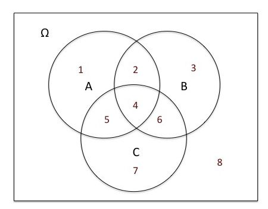

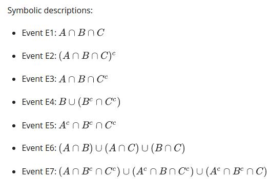

*A: At least two of the events A, B, C occur.*

- Regions 2, 4, 5, 6
- Event E6

*B: At most two of the events A, B, C occur.*

- Regions all except 4
- Event E2

*C: None of the events A, B, C occurs.*

- Region 8
- Event E5

*D: All three events A, B, C occur.*

- Region 4
- Event E1

*E: Exactly one of the events A, B, C occurs.*

- Regions 1, 3, 7
- Event E7

*F: Events A and B occur, but C does not occur.*

- Region 2
- Event E3

*G: Either event B occurs or, if not, then C also does not occur.*

- Regions 1, 2, 3, 4, 6, 8
- Event E4

**#2 Find the value of $\mathbf{P(A \cup (B^c \cup C^c)^c)}$ for each of the following cases:**  
*A: The events A, B, C are disjoint events and P(A)=2/5.*

- Same as $P(A \cup \emptyset)$, so $P(A \cup \emptyset) = P(A) = 2/5$

*B: The events A and C are disjoint, and $P(A)=1/2$ and $P(B \cap C) = 1/4$.*

- Same as $P(A \cup (B \cap C)) = P(A) + P(B \cap C) = 0.5 + 0.25 = 0.75$

*C: $P(A \cup (B^c \cup C^c)) = 0.7$*

- Using De Morgan's laws, P(interest) = 1 - 0.7 = 0.3

**#3: You flip a fair coin (i.e., the probability of obtaining Heads is 1/2) three times. Assume that all sequences of coin flip results, of length 3, are equally likely. Determine the probability of each of the following events:** *A: HHH*

- $0.5 * 0.5 * 0.5 = 0.125 = 1/8$

*B: HTH*

- Same as above = 1/8

*C: Any sequence with 2 heads and 1 tail (any order)*

- HHT, HTH, THH = 3/8

*D: Any sequence in which the number of Heads is greater than or equal to the number of Tails*

- HHH, HHT, HTH, THH = 4/8 = 0.5

**#4: Mary and Tom park their cars in an empty parking lot with n≥2 consecutive parking spaces (i.e, n spaces in a row, where only one car fits in each space). Mary and Tom pick parking spaces at random. (All pairs of parking spaces are equally likely.) What is the probability that there is at most one empty parking space between them? (Express your answer using standard notation .)**

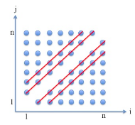

**#5:**

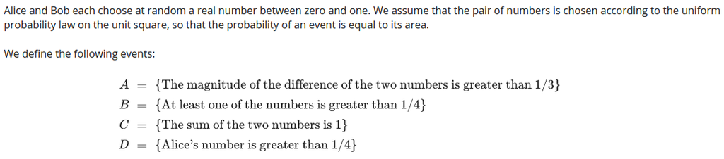

*1: $P(A)$*

- Using uniform probability law, areas apply:

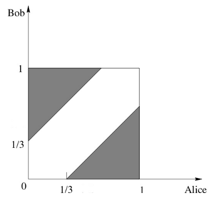

- $P(A) = 2 * 0.5 * (2/3) * (2/3) = 4/9$

*2: $P(B)$*

- Bottom left 1/4 x 1/4 area taken out $\to P(B) = 1 - 1/16 = 15/16$

*3: $P(A \cap B)$*

- A is subset of B, so $P(3) = 4/9$

*4: $P(C)$*

- Alice + Bob = 1 is line, therefore P = 0

*5: $P(D)$*

- P = 0.75

*6: $P(A \cap D)$*

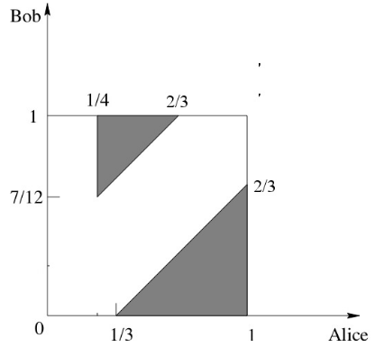

- *P = 89/288* (triangle algebra)

[output not shown]